# Gedanken zu 6) Experiments

Mir scheint es verfrüht, Detailsbeschreibungen der einzelnen Grafiken zu machen. Mir fehlt das übergeordnete große Ganze des Papers. Ich möchte einen Schritt zurückgehen und mich fragen: Was zeigt welches Experiment?

1. Was soll das Experiment zeigen?
2. Was zeigt das Experiment?
3. Sind wir damit zufrieden?
4. Falls nein, Möglichkeiten: a) Problem im Detail verstehen und versuchen, Mirmir zu verbessern, damit die Messung funktioniert. b) Ein anderes Experiment messen, um den Effekt zu zeigen. c) Die Behauptung aus dem Paper streichen, die das Experiment untermauern sollte.

```python
%load_ext autoreload
%autoreload 2
```

```python
import json
import plots
import matplotlib
from matplotlib import pyplot as plt
from pathlib import Path
```

```python
matplotlib.use("pgf")
matplotlib.rcParams.update({
    "pgf.texsystem": "xelatex",
    'font.family': 'serif',
    'text.usetex': True,
    'pgf.rcfonts': False,
})
```

## Tabelle mit allen Messungen

```python
(plots.performance_table('measurements/global-performance/2023-12-01-mirmir-baseline/',
                        'measurements/global-performance/2023-12-01-baran-baseline/',
                        '2023-12-01-baseline-baran-vs-mirmir',
                        'measurements/global-performance/2023-12-01-garf-baseline/',
                        'measurements/global-performance/2023-12-01-holoclean-baseline/')
.sort_values('normalized_dataset', ascending=True)
.loc[:, ['Mirmir', 'Baran', 'HoloClean', 'Garf']])
```

| ensemble normalized_dataset | Mirmir | Baran | HoloClean | Garf |
| --- | --- | --- | --- | --- |
| 137 5% | 0.63 | 0.58 | NaN | 0.00 |
| 137 cat 5% | 0.71 | 0.55 | NaN | 0.00 |
| 1481 5% | 0.56 | 0.53 | 0.25 | 0.02 |
| 1481 cat 5% | 1.00 | 1.00 | 1.00 | 0.00 |
| 151 5% | 0.93 | 0.86 | 0.69 | 0.34 |
| 151 cat 5% | 0.69 | 0.75 | 0.95 | 0.00 |
| 184 5% | 0.67 | 0.58 | 0.39 | 0.03 |
| 184 cat 5% | 1.00 | 1.00 | 1.00 | 0.00 |
| 41027 5% | 0.64 | 0.51 | 0.46 | 0.04 |
| 41027 cat 5% | 0.68 | 0.60 | 0.00 | 0.00 |
| 43572 5% | 0.58 | 0.52 | NaN | NaN |
| 43572 cat 5% | 0.75 | 0.33 | NaN | NaN |
| 6 5% | 0.49 | 0.45 | NaN | 0.02 |
| 6 cat 5% | 0.77 | 0.21 | NaN | 0.00 |
| beers | 0.99 | 0.90 | 0.02 | 0.00 |
| bridges 1% | 1.00 | 0.81 | 0.00 | 0.02 |
| bridges 3% | 0.82 | 0.83 | 0.01 | 0.02 |
| cars 1% | 0.93 | 0.78 | 0.00 | 0.00 |
| cars 3% | 0.52 | 0.85 | 0.00 | 0.01 |
| flights | 0.90 | 1.00 | 0.38 | 0.01 |
| glass 1% | 0.86 | 0.73 | NaN | 0.00 |
| glass 3% | 0.62 | 0.68 | NaN | 0.00 |
| hospital | 0.91 | 0.88 | NaN | 0.31 |
| rayyan | 0.42 | 0.57 | 0.00 | NaN |
| restaurant 1% | 0.65 | 0.57 | 0.00 | 0.00 |
| restaurant 3% | 0.40 | 0.40 | 0.00 | 0.00 |

**Was soll sie zeigen?**

- Mirmir ist das beste Reinigungssystem.
- Mirmir und Baran haben einen strukturellen Vorteil bei der Reinigung, weil andere Reinigungsverfahren zur Reinigung keine / schwache Ensembles benutzen.
- Es macht Sinn, Mirmir und Baran im Detail zu vergleichen, weil andere Reinigungssysteme von den Ensembles abgehängt werden.

**Was zeigt sie?**

## Mirmir vs. Baran

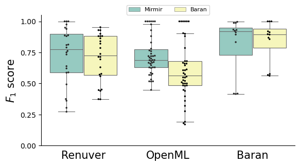

```python
fig, axes, df = plots.plot_mirmir_vs_baran('measurements/global-performance/2023-12-01-mirmir-baseline/',
                           'measurements/global-performance/2023-12-01-baran-baseline/',
                           '2023-12-01-baseline-baran-vs-mirmir')
#plt.savefig('./img/2023-12-01-mirmir-vs-baran.pgf', bbox_inches='tight')
plt.tight_layout()
plt.show()
```

**Was soll es zeigen?**

- Mirmir ist besser als Baran, weil das Gesamtensemble besser funktioniert als Barans Ensemble.

**Was zeigt es?**

- Mirmir und Baran sind gleichgut auf Baran und RENUVER
- Auf OpenML ist Mirmir klar besser.

## ET_CorrFM vs. Value Model

```
Loaded Ablation Study. 0/1320 measurements failed.
```

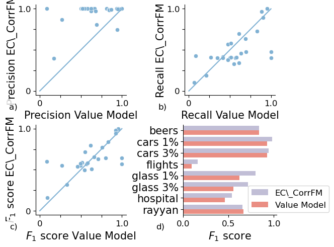

```python
plots.et_corrfm_vs_value_model('measurements/et_corfm-vs-value/', '2023-12-01-cripple-value', 'measurements/ablation-study/')
plt.show()
```

**Was soll es zeigen?**

- ET_CorrFM ist ein effektiver Ansatz, um Fehlertransformationen zu lernen.
- ET_CorrFM ist hochpräzise, und deshalb ein hervorragendes Feature für das Ensemble.

**Was zeigen es?**

- ET_CorrFM ist ein besserer Ansatz als das Value-Modell, um Fehlertransformationen zu lernen.
- ET_CorrFM ist hochpräzise.

## SC_Phodi vs. Vicinity Model

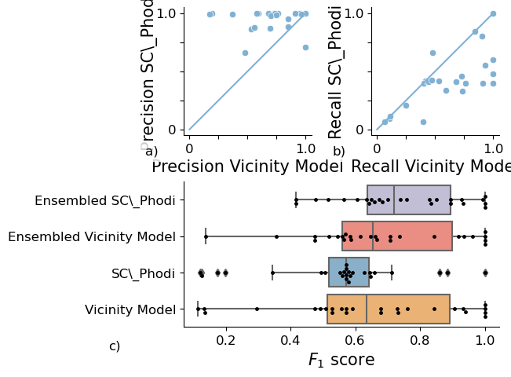

```python
fig, axes = plots.sc_phodi_vs_vicinity_model('measurements/phodi-vs-vicinity/mirmir-phodi-vs-vicinity/')
plt.show()
```

**Was soll es zeigen?**

- Phodi ist hochpräzise
- Phodi funktioniert im Ensemble besser als Vicinity

**Was zeigt es?**

- Phodi funktioniert alleine klar schlechter als das Vicinity-Model
- Das Ensemble mit Phodi funktioniert gut
- Das Vicinity-Model alleine funktioniert erstaunlich gut

## Global Ablation Study Barchart

```
Loaded Ablation Study. 0/1320 measurements failed.
```

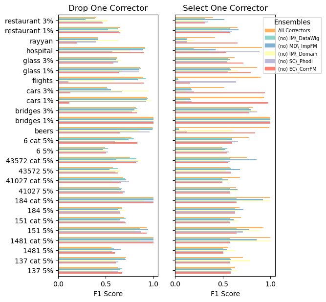

```python
from plots import plot_global_ablation_study

fig, axes = plot_global_ablation_study('measurements/ablation-study/')
plt.show()
```

**Was soll es zeigen?**

- Das Ensemble von Mirmir ist sinnvoll gewählt.
- Jeder Corrector hat Stärken und Schwächen.

**Was zeigt es?**

- Die Performance einzelner Correctors ist vom Datensatz abhängig
- Für eine externe Person aus Felix' Gruppe zeigt die Grafik ziemlich wenig, weil es so gelanden mit Informationen ist.

## Local Ablation Study Barchart

```
Loaded Ablation Study. 0/1320 measurements failed.
```

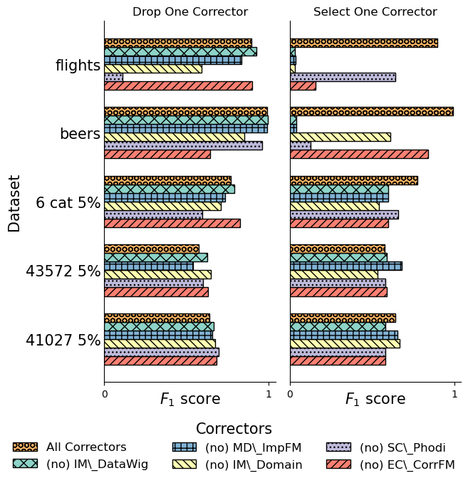

```python
from plots import plot_local_ablation_study

fig, axes = plot_local_ablation_study('measurements/ablation-study/')
plt.tight_layout()
plt.show()
```

**Was soll es zeigen?**

- Beispielhaft je einen Datensatz, auf dem ein Corrector stark ist.

**Was zeigt es?**

- Nach meinem letzten Messlauf klappen die Datensätze 43572, 6 cat 5% und 41027 nicht so, wie ich das gerne hätte :-)